# Uygulama - Öngörü (Forecasting)

Finansal Ekonometri (MPİ-TYL)

Prof. Dr. Hüseyin Taştan

Yıldız Teknik Üniversitesi

# 1 Basit öngörü modelleri

```r
# Sys.getlocale()
# ayarları TR'ye uyarlamak için:
Sys.setlocale("LC_ALL", "turkish") #
```

```
## [1] "LC_COLLATE=Turkish_Turkey.1254;LC_CTYPE=Turkish_Turkey.1254;LC_MONETARY=Turkish_Turkey.1254;LC_NUMERIC=C;LC_TIME=Turkish_Turkey.1254"
```

```r
library(tidyverse)
library(forecast)
```

## 1.1 Örnek: İstanbul’da sıcaklıklar

```r
# İstanbul hava durumu verilerini yükleyelim
load("Data/weather_istanbul.rda")
# Sıcaklık için bir ts nesnesi oluştur:
temp_ist <- ts(weather_istanbul$temp, # ts nesnesi oluştur
               start=c(2000, 1),      # dönem: 2000.1-2014.12
               frequency = 12)
tail(temp_ist) # son altı gözlem
```

```
##       Jul  Aug  Sep  Oct  Nov  Dec
## 2014 26.1 26.5 22.1 17.4 12.6 10.5
```

1 dönem sonrası için basit ortalama, naif ve mevsimsel naif öngörüleri oluşturalım:

```r
# h=1 için öngörüler
meanf(temp_ist, h=1)  # ortalama öngörüsü, öngörü ufku h
```

```
##          Point Forecast    Lo 80    Hi 80    Lo 95    Hi 95
## Jan 2015       15.48333 6.511874 24.45479 1.720258 29.24641
```

```r
naive(temp_ist, h=1)  # naif öngörü
```

```
##          Point Forecast   Lo 80    Hi 80    Lo 95    Hi 95
## Jan 2015           10.5 5.52081 15.47919 2.884987 18.11501
```

```r
snaive(temp_ist, h=1) # mevsimsel naif
```

```
##          Point Forecast    Lo 80    Hi 80    Lo 95   Hi 95
## Jan 2015            9.5 6.808106 12.19189 5.383104 13.6169
```

`{forecast}` paketinde yer alan `meanf()`, `naive()`, ve `snaive()` fonksiyonları bir dönem sonrası (2015 Ocak) için nokta öngörüsü oluşturdu ve bunun %80 ve %95 güven aralıklarını hesapladı.

6 aylık öngörüler hesaplamak istersek:

```r
# h=6 için öngörüler
h <- 6
meanf(temp_ist, h=h)  # ortalama öngörüsü, öngörü ufku h
```

```
##          Point Forecast    Lo 80    Hi 80    Lo 95    Hi 95
## Jan 2015       15.48333 6.511874 24.45479 1.720258 29.24641
## Feb 2015       15.48333 6.511874 24.45479 1.720258 29.24641
## Mar 2015       15.48333 6.511874 24.45479 1.720258 29.24641
## Apr 2015       15.48333 6.511874 24.45479 1.720258 29.24641
## May 2015       15.48333 6.511874 24.45479 1.720258 29.24641
## Jun 2015       15.48333 6.511874 24.45479 1.720258 29.24641
```

```r
naive(temp_ist, h=h)  # naif öngörü
```

```
##          Point Forecast      Lo 80    Hi 80      Lo 95    Hi 95
## Jan 2015           10.5  5.5208103 15.47919  2.8849865 18.11501
## Feb 2015           10.5  3.4583624 17.54164 -0.2692554 21.26926
## Mar 2015           10.5  1.8757905 19.12421 -2.6895903 23.68959
## Apr 2015           10.5  0.5416206 20.45838 -4.7300270 25.73003
## May 2015           10.5 -0.6338066 21.63381 -6.5276878 27.52769
## Jun 2015           10.5 -1.6964741 22.69647 -8.1528974 29.15290
```

```r
snaive(temp_ist, h=h) # mevsimsel naif
```

```
##          Point Forecast     Lo 80    Hi 80     Lo 95   Hi 95
## Jan 2015            9.5  6.808106 12.19189  5.383104 13.6169
## Feb 2015            9.5  6.808106 12.19189  5.383104 13.6169
## Mar 2015           11.4  8.708106 14.09189  7.283104 15.5169
## Apr 2015           15.0 12.308106 17.69189 10.883104 19.1169
## May 2015           19.0 16.308106 21.69189 14.883104 23.1169
## Jun 2015           22.7 20.008106 25.39189 18.583104 26.8169
```

24 aylık öngörüler oluşturalım ve grafiklerini çizelim:

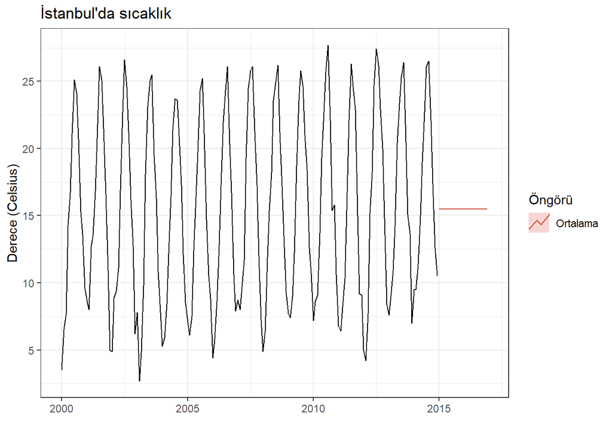

```r
# h=24 için basit ortalama öngörüsü
autoplot(temp_ist) +
  autolayer(meanf(temp_ist, h=24), PI=FALSE, series="Ortalama") +
  scale_y_continuous(breaks=seq(0,25,5)) +
  theme_bw() +
  ggtitle("İstanbul'da sıcaklık") +
  xlab("") + ylab("Derece (Celsius)") +
  guides(colour=guide_legend(title="Öngörü"))
```

Öngörü güven aralığına göstermek istersek:

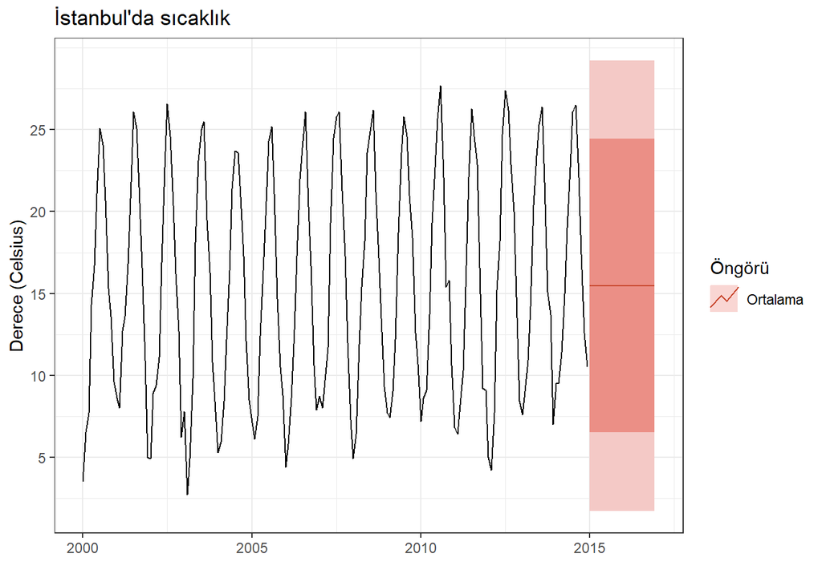

```r
# h=24 için basit ortalama öngörüsü
autoplot(temp_ist) +
  autolayer(meanf(temp_ist, h=24), PI=TRUE, series="Ortalama") +
  scale_y_continuous(breaks=seq(0,25,5)) +
  theme_bw() +
  ggtitle("İstanbul'da sıcaklık") +
  xlab("") + ylab("Derece (Celsius)") +
  guides(colour=guide_legend(title="Öngörü"))
```

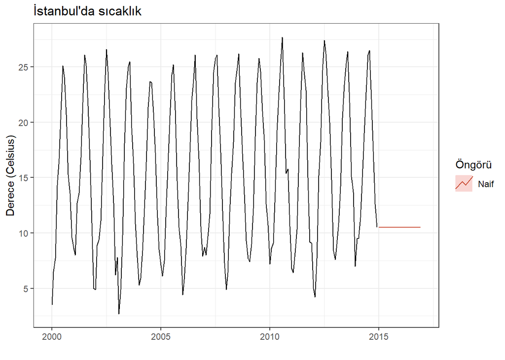

```r
# Naif öngörü
autoplot(temp_ist) +
  autolayer(naive(temp_ist, h=24), PI=FALSE, series="Naif") +
  scale_y_continuous(breaks=seq(0,25,5)) +
  theme_bw() +
  ggtitle("İstanbul'da sıcaklık") +
  xlab("") + ylab("Derece (Celsius)") +
  guides(colour=guide_legend(title="Öngörü"))
```

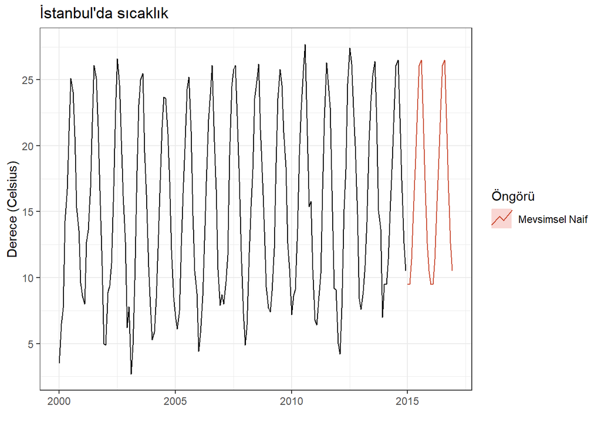

```r
# Mevsimsel Naif öngörü
autoplot(temp_ist) +
  autolayer(snaive(temp_ist, h=24), PI=FALSE, series="Mevsimsel Naif") +
  scale_y_continuous(breaks=seq(0,25,5)) +
  theme_bw() +
  ggtitle("İstanbul'da sıcaklık") +
  xlab("") + ylab("Derece (Celsius)") +
  guides(colour=guide_legend(title="Öngörü"))
```

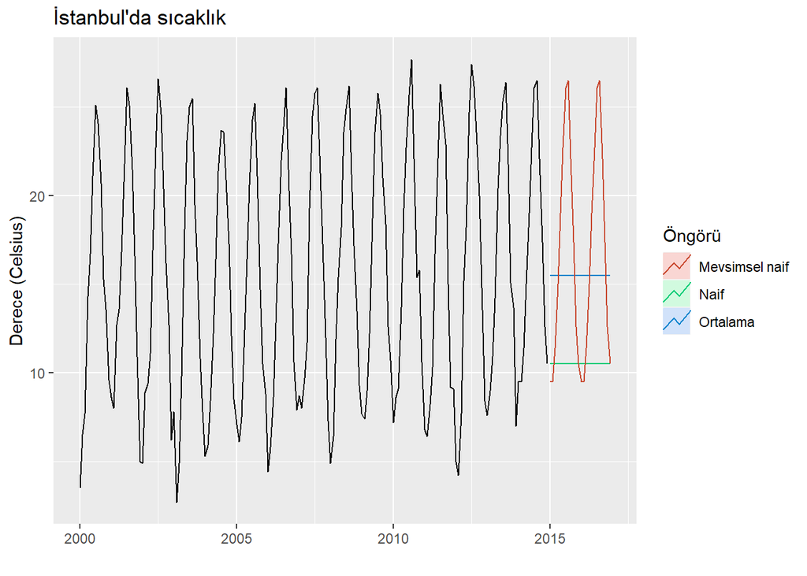

```r
# Birlikte
autoplot(temp_ist) +
  autolayer(meanf(temp_ist, h=24), PI=FALSE, series="Ortalama") +
  autolayer(naive(temp_ist, h=24), PI=FALSE, series="Naif") +
  autolayer(snaive(temp_ist, h=24), PI=FALSE, series="Mevsimsel naif") +
  ggtitle("İstanbul'da sıcaklık") +
  xlab("") + ylab("Derece (Celsius)") +
  guides(colour=guide_legend(title="Öngörü"))
```

## 1.2 Örnek: Google günlük hisse fiyatları

Bu örnekte `{tsibbledata}` paketinde yer alan `gafa_stock` verilerini kullanacağız.

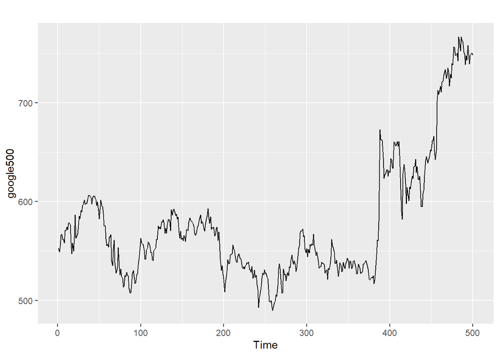

```r
# Drift yöntemi
# google günlük hisse verileri
library(tsibble)
library(tsibbledata)
google <- gafa_stock %>% filter(Symbol == "GOOG")
google_ts <- ts(google$Close, frequency = 1)
google500 <- window(google_ts, end = 500)
autoplot(google500)
```

Bir gün sonrası için drift öngörüsü

```r
rwf(google500, 1, drift=TRUE)
```

```
##     Point Forecast   Lo 80    Hi 80    Lo 95    Hi 95
## 501       748.7917 736.656 760.9273 730.2318 767.3515
```

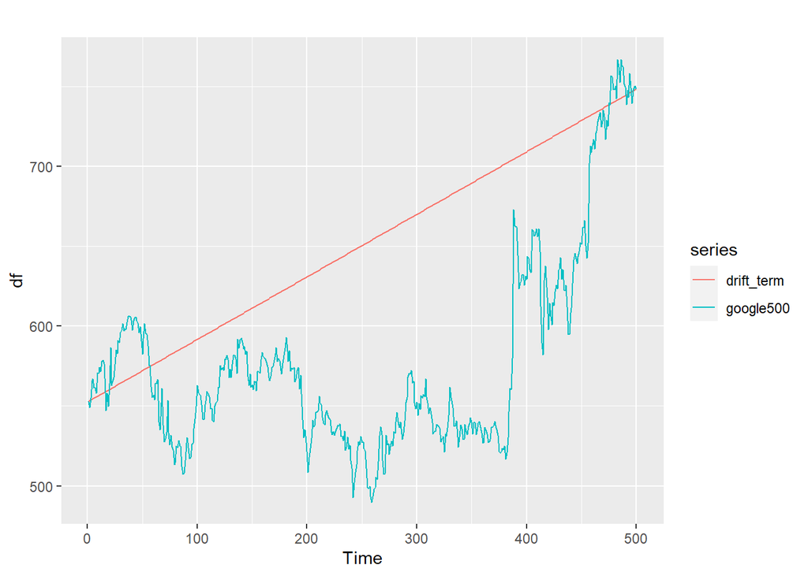

```r
# drift: zaman içindeki düzenli artış (veya azalış)
dr <- (google500[500]-google500[1])/499
drift_term <- google500[1] + seq(0,499,1)*dr
drift_term <- ts(drift_term)
df <- cbind(drift_term, google500)
autoplot(df)
```

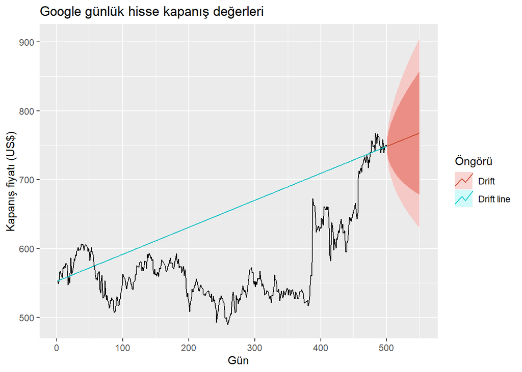

```r
# Drift öngörüleri
# h=50 gün
autoplot(google500) +
  autolayer(drift_term, series = "Drift line") +
  autolayer(rwf(google500, drift=TRUE, h=50),
            series="Drift", PI=TRUE) +
  ggtitle("Google günlük hisse kapanış değerleri") +
  xlab("Gün") + ylab("Kapanış fiyatı (US$)") +
  guides(colour=guide_legend(title="Öngörü"))
```

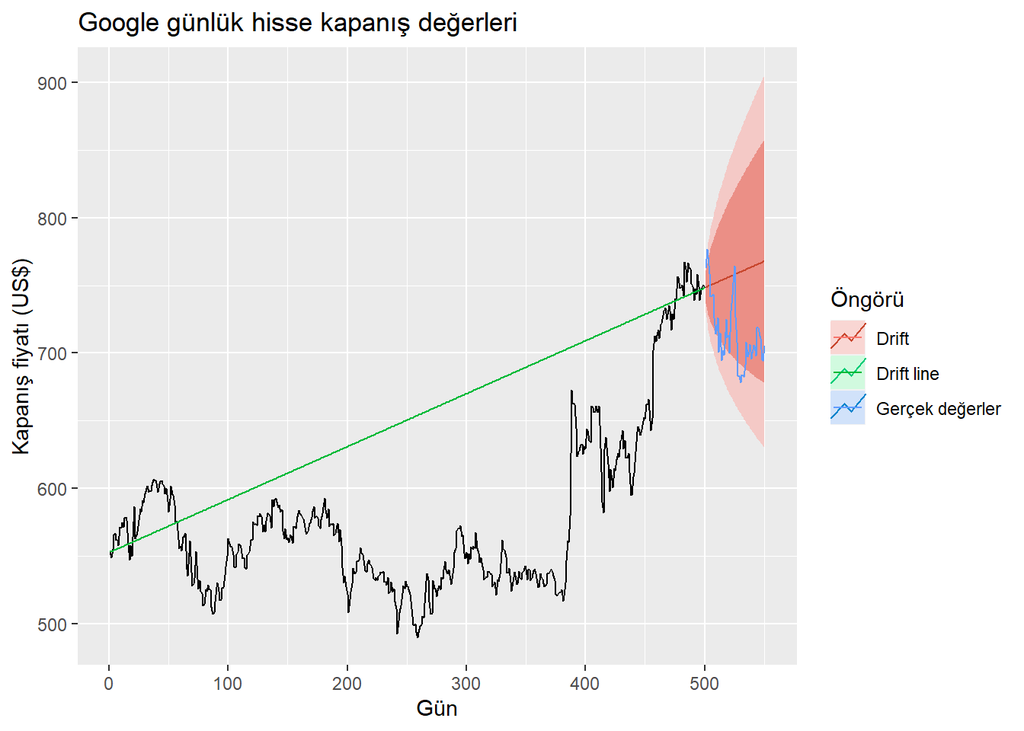

```r
# Drift öngörüleri
# h=50 gün
# gerçekleşen değerleri ekle
google550 <- window(google_ts, start = 501, end = 550)

autoplot(google500) +
  autolayer(drift_term, series = "Drift line") +
  autolayer(rwf(google500, drift=TRUE, h=50),
            series="Drift", PI=TRUE) +
  autolayer(google550, series = "Gerçek değerler") +
  ggtitle("Google günlük hisse kapanış değerleri") +
  xlab("Gün") + ylab("Kapanış fiyatı (US$)") +
  guides(colour=guide_legend(title="Öngörü"))
```

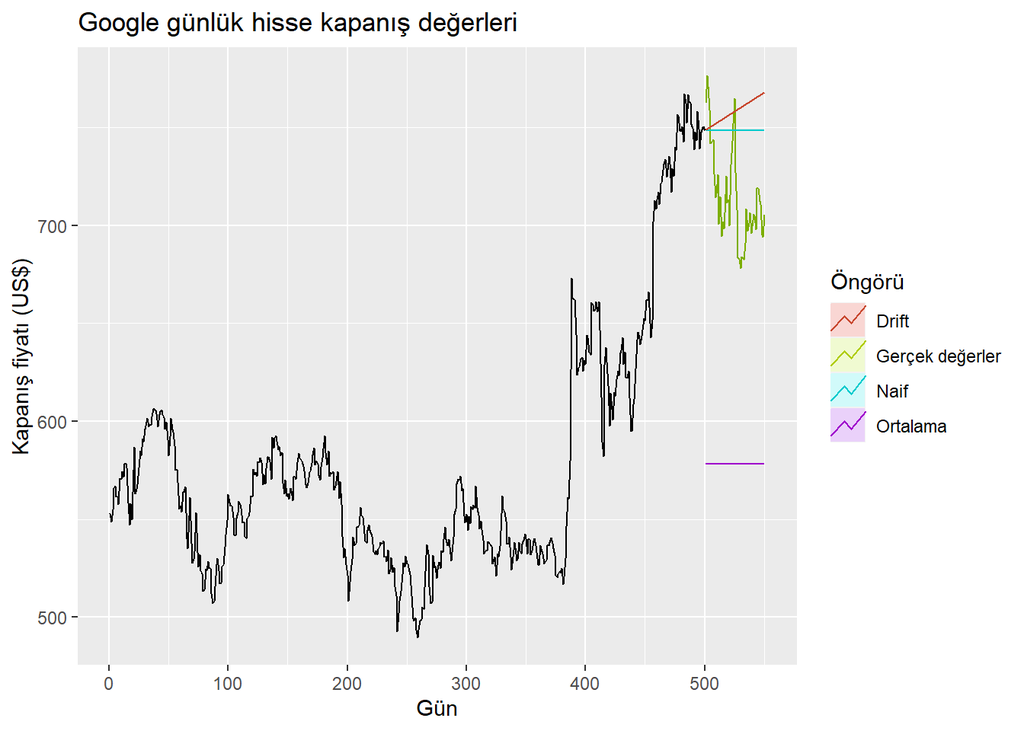

```r
# diğer öngörüler
autoplot(google500) +
  autolayer(google550, series = "Gerçek değerler") +
  autolayer(meanf(google500, h=50),
            series="Ortalama", PI=FALSE) +
  autolayer(rwf(google500, h=50),
            series="Naif", PI=FALSE) +
  autolayer(rwf(google500, drift=TRUE, h=50),
            series="Drift", PI=FALSE) +
  ggtitle("Google günlük hisse kapanış değerleri") +
  xlab("Gün") + ylab("Kapanış fiyatı (US$)") +
  guides(colour=guide_legend(title="Öngörü"))
```

# 2 Dönüştürmeler

```r
# Box-Cox transformasyonu örnek
load("Data/turist.rda")
turist_ts <- ts(turist$touristnumber,
                start = c(1990,1),
                frequency = 12)
```

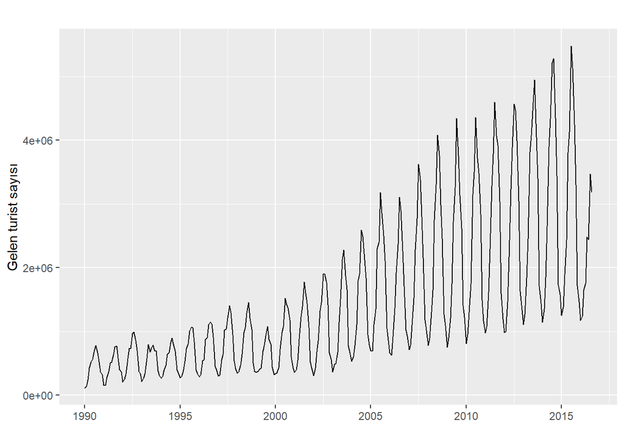

```r
# plot
autoplot(turist_ts) +
  xlab("") +
  ylab("Gelen turist sayısı")
```

```r
(lambda <- BoxCox.lambda(turist_ts))
```

```
## [1] -0.0705619
```

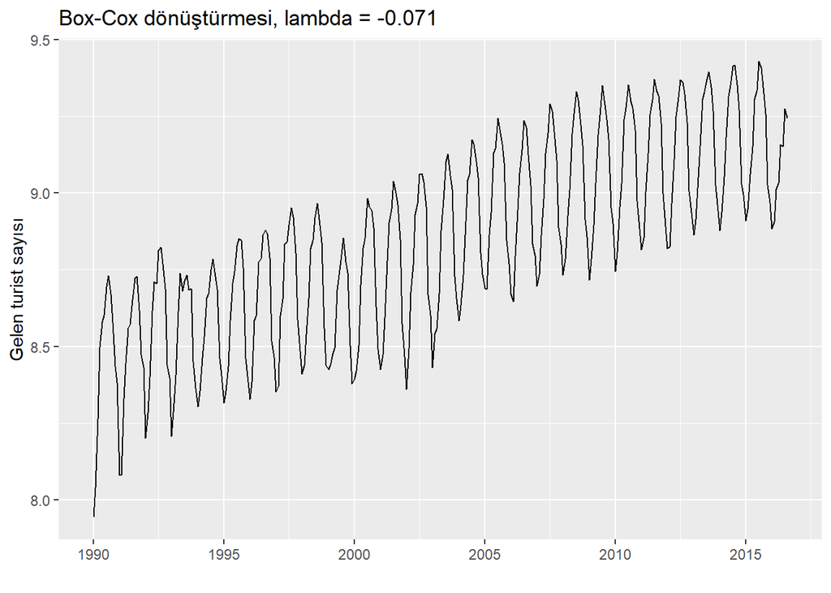

```r
autoplot(BoxCox(turist_ts,lambda)) +
  xlab("") +
  ggtitle("Box-Cox dönüştürmesi, lambda = -0.071") +
  ylab("Gelen turist sayısı")
```

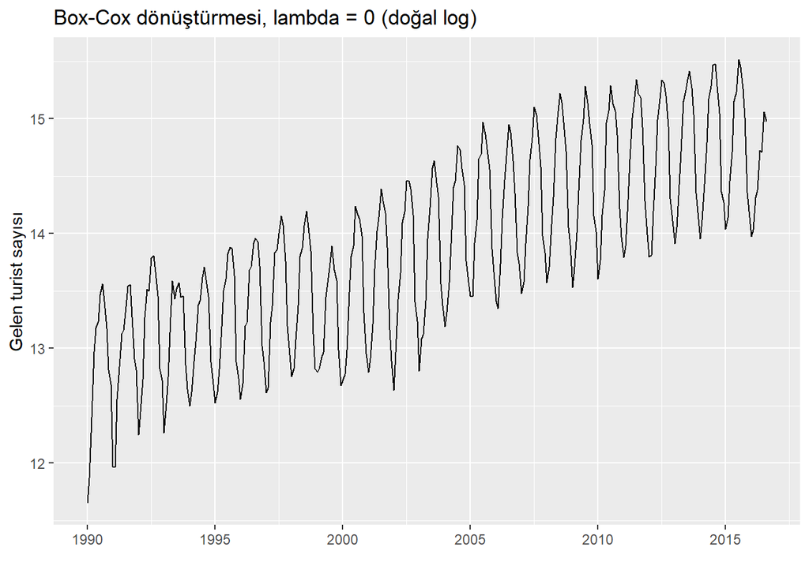

```r
# lambda=0 (log)
autoplot(BoxCox(turist_ts,0)) +
  xlab("") +
  ggtitle("Box-Cox dönüştürmesi, lambda = 0 (doğal log)") +
  ylab("Gelen turist sayısı")
```

# 3 Kalıntı analizi

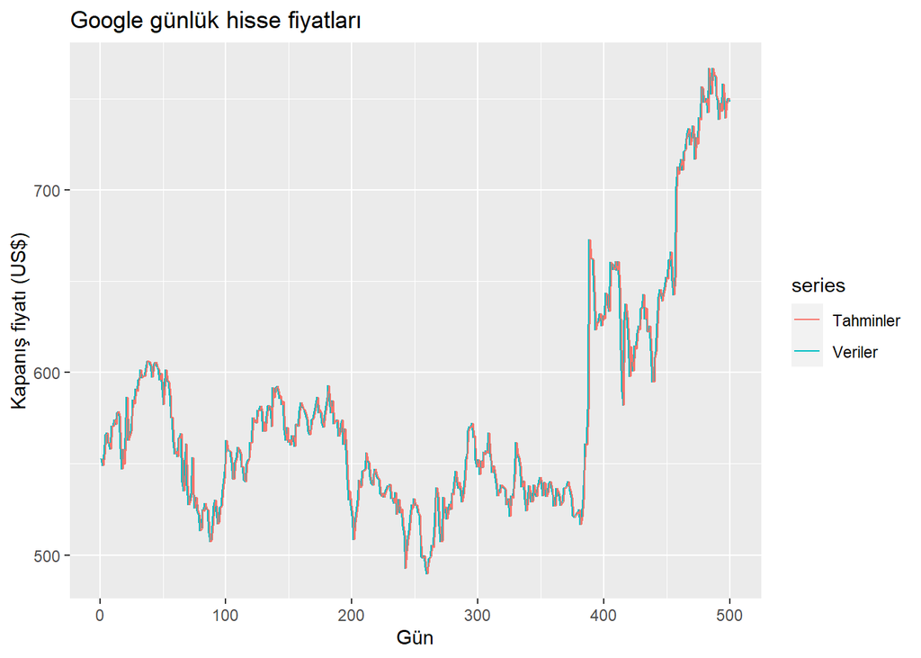

```r
# Kalıntı analizi
# Google hisseleri
naif_fit1 <- naive(google500)
naif_tahminler <- fitted(naif_fit1)

autoplot(google500, series="Veriler") +
  autolayer(naif_tahminler, series="Tahminler") +
  xlab("Gün") + ylab("Kapanış fiyatı (US$)") +
  ggtitle("Google günlük hisse fiyatları")
```

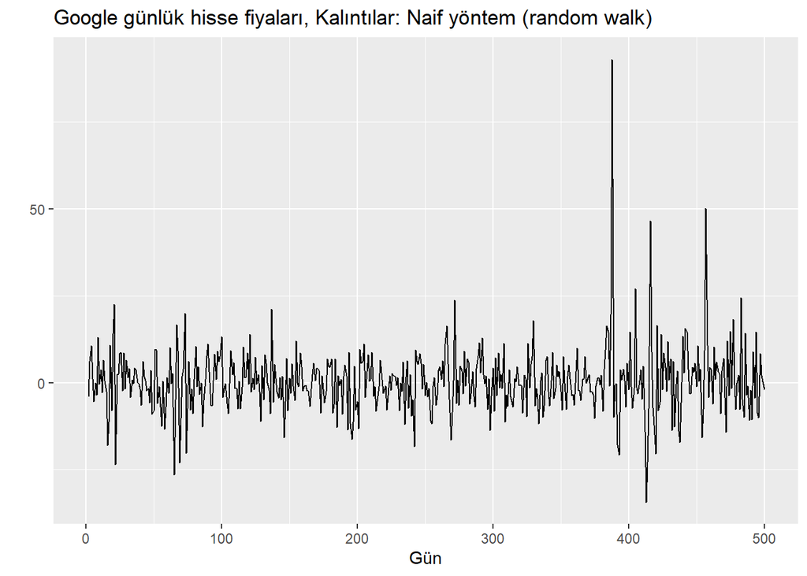

```r
naif_resid <- residuals(naif_fit1)

autoplot(naif_resid) +
  xlab("Gün") +
  ylab("") +
  ggtitle("Google günlük hisse fiyaları, Kalıntılar: Naif yöntem (random walk)")
```

```r
# not: naif öngörüde yarın için öngörü bugün gözlenen kapanış değeri olduğu için
# kalıntılar günlük değişimlere eşittir. Random Walk sürecini takip eden bir seri
# için yapılabilecek en iyi öngörü son gözlenen değerdir.
```

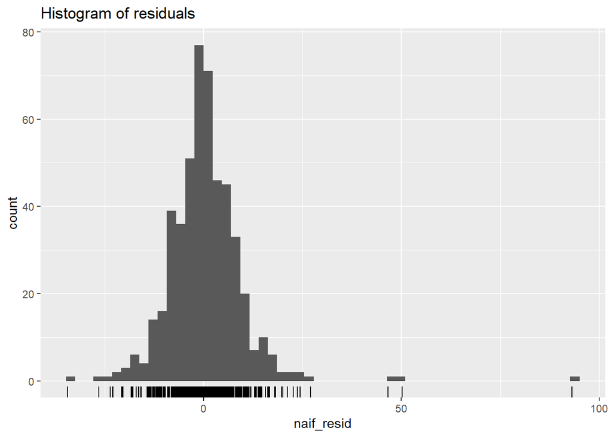

```r
# kalıntıların analizi
gghistogram(naif_resid) + ggtitle("Histogram of residuals")
```

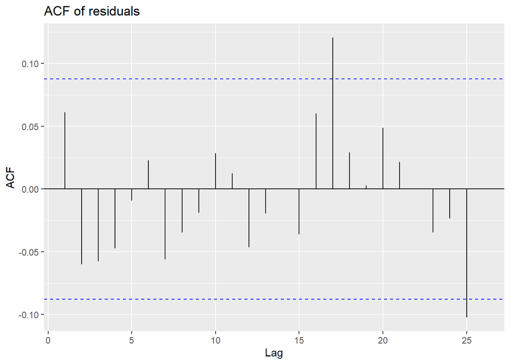

```r
ggAcf(naif_resid) + ggtitle("ACF of residuals")
```

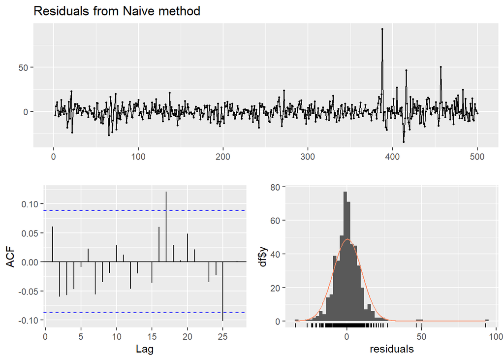

```
##
##  Ljung-Box test
##
## data:  Residuals from Naive method
## Q* = 9.5917, df = 10, p-value = 0.477
##
## Model df: 0.   Total lags used: 10
```

```r
checkresiduals(naif_fit1)
```

```r
# veya
# checkresiduals(naive(google500))
```

Ljung-Box Q istatistiğinin boş hipotezi 10uncu gecikmeye kadar otokorelasyonların sıfır olduğunu söyler (otokorelasyon yoktur). P değeri 0.477 olarak hesaplanmıştır. Öyleyse boş hipotez kabul edilir. Kalıntılarda otokeralasyon yoktur.

# 4 Öngörü performansının ölçümü

```r
# İstanbul'da sıcaklıklar
# 2013-2014 yılları test kümesi olarak ayrıldı:
temp_ist_train <- window(temp_ist,start=c(2000,1),end=c(2012,12))
temp_ist_test <- window(temp_ist,start=c(2013,1))
```

h=24 için basit öngörüleri oluşturalım:

```r
temp_ist_fit1 <- meanf(temp_ist_train, h=24)
temp_ist_fit2 <- rwf(temp_ist_train, h=24)
temp_ist_fit3 <- snaive(temp_ist_train, h=24)
```

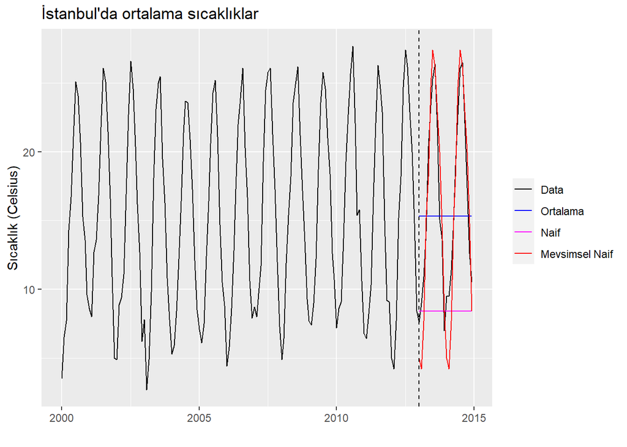

```r
# plot data and forecasts
autoplot(temp_ist, series="Data") +
  autolayer(temp_ist_fit1$mean, series="Ortalama") +
  autolayer(temp_ist_fit2$mean, series="Naif")+
  autolayer(temp_ist_fit3$mean, series="Mevsimsel Naif") +
  geom_vline(xintercept = 2013, linetype=2) +
  scale_colour_manual(values=c("black","blue","magenta","red"),
                      breaks=c("Data","Ortalama", "Naif","Mevsimsel Naif" )) +
  ggtitle("İstanbul'da ortalama sıcaklıklar") +
  xlab("") + ylab("Sıcaklık (Celsius)") +
  theme(legend.title = element_blank())
```

Öngörü yaptığımız dönem veri setimizde mevcut, yani gerçek değerleri biliyoruz. Buradan hareketle öngörü hatalarını hesaplayabiliriz.

```r
# Öngörü performansı
accuracy(temp_ist_fit1, temp_ist_test)
```

```
##                        ME     RMSE      MAE        MPE     MAPE     MASE
## Training set 7.457532e-16 6.999638 6.177819 -32.119769 58.73207 3.876279
## Test set     1.225962e+00 6.522497 5.655823  -9.596542 38.64511 3.548751
##                   ACF1 Theil's U
## Training set 0.8315966        NA
## Test set     0.7810418  1.759382
```

```r
accuracy(temp_ist_fit2, temp_ist_test)
```

```
##                     ME      RMSE      MAE       MPE     MAPE     MASE      ACF1
## Training set 0.0316129  3.924029 3.421290 -4.831335 27.37688 2.146692 0.6491866
## Test set     8.1458333 10.363136 8.329167 39.907399 42.45126 5.226144 0.7810418
##              Theil's U
## Training set        NA
## Test set      2.165843
```

```r
accuracy(temp_ist_fit3, temp_ist_test)
```

```
##                     ME     RMSE      MAE       MPE     MAPE     MASE      ACF1
## Training set 0.1145833 2.098495 1.593750 -2.852270 16.43041 1.000000 0.2661973
## Test set     0.3208333 2.626389 2.154167  6.326211 17.79047 1.351634 0.4460066
##              Theil's U
## Training set        NA
## Test set      1.089741
```

RMSE kriterine göre en başarılı yöntem test verilerinde en düşük değeri (2.626) veren mevsimsel naif öngörü yöntemidir. Diğer kriterlere göre de en başarılı yöntemdir.

Zaman serisi çapraz-geçerleme örneği:

```r
# TS cross-validation
# forecast accuracy average over test sets
# evaluation on a rolling forecast origin
hata <- tsCV(y = google500,       # verileri
          forecastfunction = rwf, # random walk öngörüleri
          drift = TRUE,           # drift terimi dahil
          h = 1,                  # öngörü ufku
          window = 400)           # pencere genişliği
```

Yukarıdaki komutlarda ilk 400 gözlem eğitim setinde kullanılır ve bir dönem sonrası için öngörü oluşturulduktan sonra `hata` hesaplanır. Bir dönem sonrasının gerçekleşen değeri eğitim setine eklenir ve tekrar model eğitilir. Yine bir dönem sonrası için öngörü oluşturulur ve `hata` hesaplanır. Bu şekilde adımlar yinelenerek 400-500 arası tüm gözlemler için öngörü hatası ve başarısı (örneğin MSE veya RMSE) hesaplanabilir.

```r
# RMSE =
sqrt(mean(hata^2, na.rm=TRUE))
```

```
## [1] 12.11996
```

# 5 KPSS Durağanlık Testi

Değişkenlerin birinci farkını almalı mıyız? Durağan olmayan bir zaman serisini (random walk ya da random walk with drift gibi) durağanlaştırmanın tek yolu birinci farkını almaktır. Literatürde çok sayıda birim kök testi geliştirilmiştir. Yaygın olarak kullanılan testler ADF testi (Augmented Dickey-Fuller) ve KPSS testidir.

KPSS testinin boş hipotezi değişkenin **durağan olduğunu** söyler:
$$H_0:~~seri~durağandır$$

$$H_1:~~seri~durağan~değildir$$

KPSS test istatistiğinin p değeri ile karar verilebilir. Yeterince büyük bir p değeri (örneğin 0.05’den büyükse) boş hipotez kabul edilir, yani seri durağandır.

Örnek:

```r
library(urca) # birim kök ve durağanlık testleri için paket
# KPSS testi, urca paketi
kpss1 <- ur.kpss(log(google500))
summary(kpss1)
```

```
##
## #######################
## # KPSS Unit Root Test #
## #######################
##
## Test is of type: mu with 5 lags.
##
## Value of test-statistic is: 2.9062
##
## Critical value for a significance level of:
##                 10pct  5pct 2.5pct  1pct
## critical values 0.347 0.463  0.574 0.739
```

KPSS test istatistiği 2.9062 kritik değerlerden büyüktür. Sonuç olarak boş hipotez reddedilir. Boş hipotez serinin durağan olduğunu söylüyordu. Öyleyse seri durağan değildir. KPSS testi `feasts::unitroot_kpss()` fonksiyonu ile de hesaplanabilir:

```r
feasts::unitroot_kpss(log(google500))
```

```
##   kpss_stat kpss_pvalue
##    2.906176    0.010000
```

P değeri 0.01 olduğuna göre $H_0$ reddedilir, seri durağan değildir.

Birinci fark ile tekrarlayalım:

```r
feasts::unitroot_kpss(diff(log(google500)))
```

```
##   kpss_stat kpss_pvalue
##   0.1790407   0.1000000
```

P değeri 0.05’den büyüktür. Boş hipotez kabul edilir, birinci fark durağandır.

Bir değişkenin durağanlaşması için kaç farkının alınması gerektiğini otomatik olarak `feasts::unitroot_ndiffs()` fonksiyonu ile de hesaplayabiliriz. Bu fonksiyonu KPSS testini kullanmaktadır. Google serisine uygularsak:

```r
feasts::unitroot_ndiffs(log(google500))
```

```
## ndiffs
##      1
```

Log google değişkeninin birinci farkının alınması seriyi durağanlaştırmaktadır. Birinci fark için:

```r
feasts::unitroot_ndiffs(diff(log(google500)))
```

```
## ndiffs
##      0
```

Tekrar fark almaya gerek yoktur.

Değişkenin mevsimsel farkını almalı mıyız? Bu amaçla `feasts::nsdiffs()` bu amaçla kullanılabilir:

```r
feasts::unitroot_nsdiffs(log(turist_ts))
```

```
## nsdiffs
##       0
```

Bu sonuca göre turist sayısının mevsimsel farkını almaya gerek yoktur. Ancak birinci farkını almak gerekir:

```r
feasts::unitroot_ndiffs(log(turist_ts))
```

```
## ndiffs
##      1
```

# 6 ARIMA modelleri

## 6.1 Örnek: Sanayi Üretim Endeksi

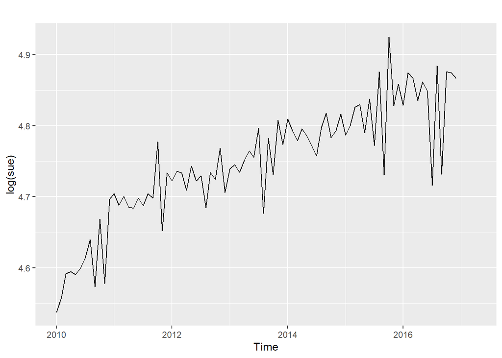

```r
load("Data/tr_macro_monthly.rda")
sue_full <- ts(tr_macro_monthly$ipi_sa, start = c(1986,1), frequency = 12)
# Alt dönem: 2010 sonrası için SUE
sue <- window(sue_full, start = c(2010,1))
autoplot(log(sue))
```

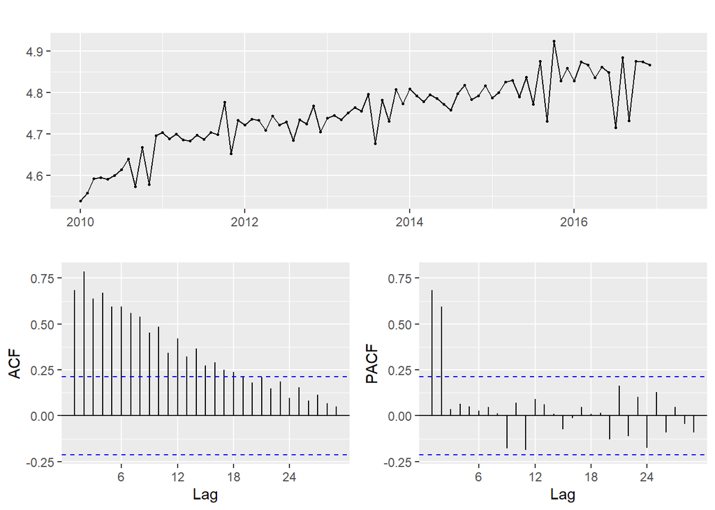

```r
ggtsdisplay(log(sue))
```

ACF üstel olarak yavaş bir şekilde azalıyor, PACF ise 2nci gecikmeden sonra sıfır kabul edilebilir.

Birim kök testi:

```r
# KPSS
library(feasts)
unitroot_kpss(log(sue))
```

```
##   kpss_stat kpss_pvalue
##      2.0097      0.0100
```

Sanay üretim endeksinin durağan olduğunu söyleyen boş hipotez reddedilir. Birinci farkını alarak tekrar testi hesaplayalım:

```r
unitroot_kpss(diff(log(sue)))
```

```
##   kpss_stat kpss_pvalue
##  0.07969681  0.10000000
```

P değeri yeterince büyük olduğu için boş hipotez kabul edilir. Sonuç olarak SÜE serisi birinci farkı alındığında durağanlaşmaktadır.

```r
unitroot_ndiffs(log(sue))
```

```
## ndiffs
##      1
```

```r
unitroot_nsdiffs(log(sue))
```

```
## nsdiffs
##       0
```

Birinci fark almaya gerek vardır ancak mevsimsel fark almaya gerek yoktur.

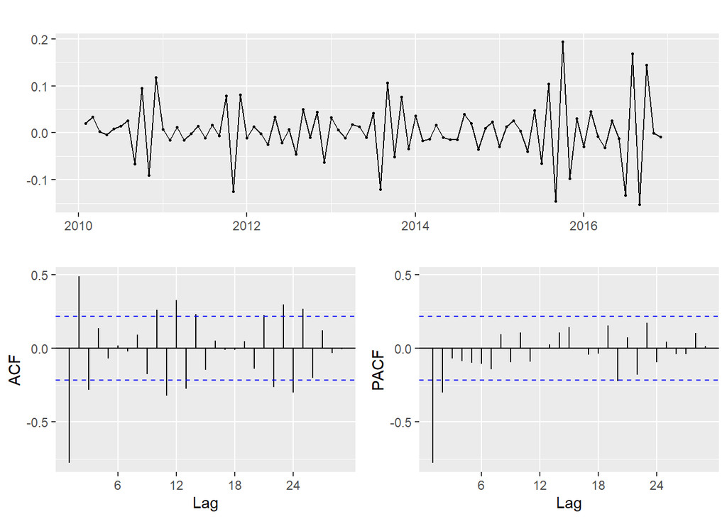

```r
ggtsdisplay(diff(log(sue)))
```

ARIMA(1,1,1) modeli:

```r
fit1 <- Arima(log(sue), order=c(1,1,1))
fit1
```

```
## Series: log(sue)
## ARIMA(1,1,1)
##
## Coefficients:
##           ar1      ma1
##       -0.6326  -0.3510
## s.e.   0.1051   0.1349
##
## sigma^2 = 0.001447:  log likelihood = 154.05
## AIC=-302.11   AICc=-301.8   BIC=-294.85
```

Kalıntıların incelenmesi:

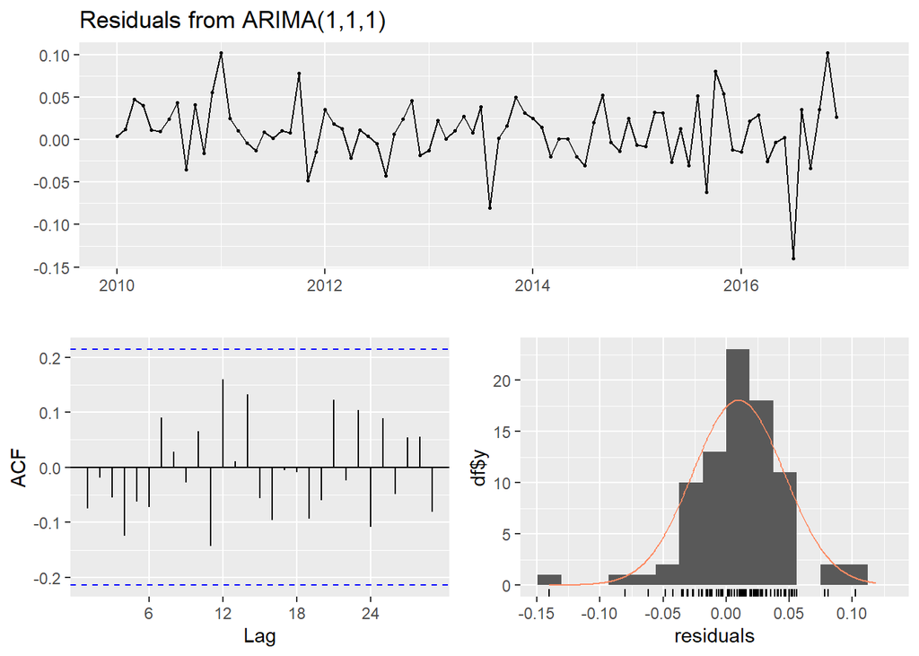

```
##
##  Ljung-Box test
##
## data:  Residuals from ARIMA(1,1,1)
## Q* = 12.06, df = 16, p-value = 0.7399
##
## Model df: 2.   Total lags used: 18
```

```r
checkresiduals(fit1)
```

Kalıntıların ACF grafiği ve Ljung-Box istatistikleri ARIMA(1,1,1) modelinin uygun olduğunu göstermektedir.

```r
fit2 <- Arima(log(sue), order=c(2,1,1), include.drift = TRUE)
fit2
```

```
## Series: log(sue)
## ARIMA(2,1,1) with drift
##
## Coefficients:
##           ar1     ar2      ma1   drift
##       -0.3341  0.2319  -0.7396  0.0035
## s.e.   0.2074  0.1894   0.1623  0.0010
##
## sigma^2 = 0.001351:  log likelihood = 157.79
## AIC=-305.58   AICc=-304.8   BIC=-293.48
```

Kalıntıların incelenmesi:

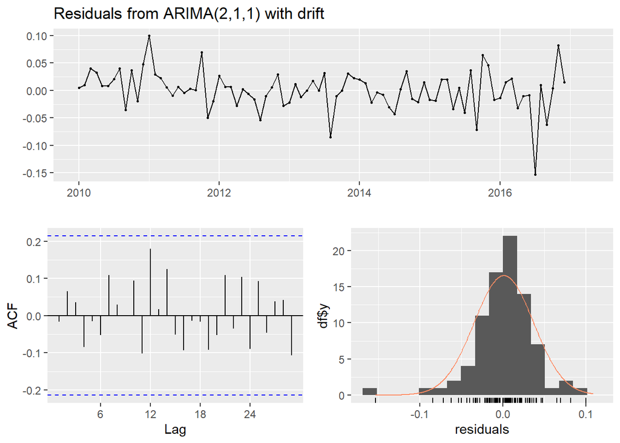

```
##
##  Ljung-Box test
##
## data:  Residuals from ARIMA(2,1,1) with drift
## Q* = 10.621, df = 15, p-value = 0.779
##
## Model df: 3.   Total lags used: 18
```

```r
checkresiduals(fit2)
```

ARIMA(2,1,1) modelinin kalıntıları da white noise, hangi model daha uygun? Bunun için AIC değeri en küçük olan tercih edilebilir.

ARIMA(1,1,1) için AIC=-302.11 AICc=-301.8

ARIMA(2,1,1) için AIC=-305.58 AICc=-304.8

Bu sonuçlara göre ARIMA(2,1,1) daha küçük bir AIC değerine sahip olduğu için tercih edilebilir.

Otomatik ARIMA seçimi (Hyndman-Khandakar algoritması)

```r
auto.arima(log(sue))
```

```
## Series: log(sue)
## ARIMA(1,1,1)(0,0,1)[12] with drift
##
## Coefficients:
##          ar1      ma1    sma1   drift
##       -0.490  -0.5479  0.3708  0.0038
## s.e.   0.133   0.1412  0.1437  0.0016
##
## sigma^2 = 0.001261:  log likelihood = 159.89
## AIC=-309.79   AICc=-309.01   BIC=-297.7
```

Bu algoritma ARIMA(1,1,1)(0,0,1)[12] mevsimsel ARIMA modelini seçti

```r
fit3 <- Arima(log(sue), order=c(1,1,1), seasonal = c(0,0,1), include.drift = TRUE)
fit3
```

```
## Series: log(sue)
## ARIMA(1,1,1)(0,0,1)[12] with drift
##
## Coefficients:
##          ar1      ma1    sma1   drift
##       -0.490  -0.5479  0.3708  0.0038
## s.e.   0.133   0.1412  0.1437  0.0016
##
## sigma^2 = 0.001261:  log likelihood = 159.89
## AIC=-309.79   AICc=-309.01   BIC=-297.7
```

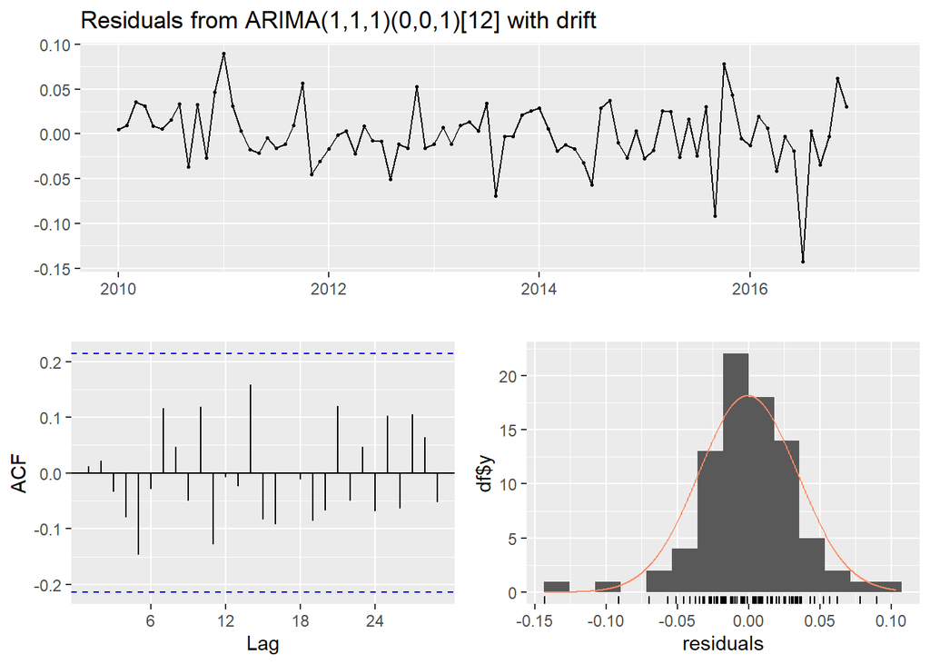

```
##
##  Ljung-Box test
##
## data:  Residuals from ARIMA(1,1,1)(0,0,1)[12] with drift
## Q* = 11.796, df = 15, p-value = 0.6944
##
## Model df: 3.   Total lags used: 18
```

```r
checkresiduals(fit3)
```

ARIMA ile öngörüler:

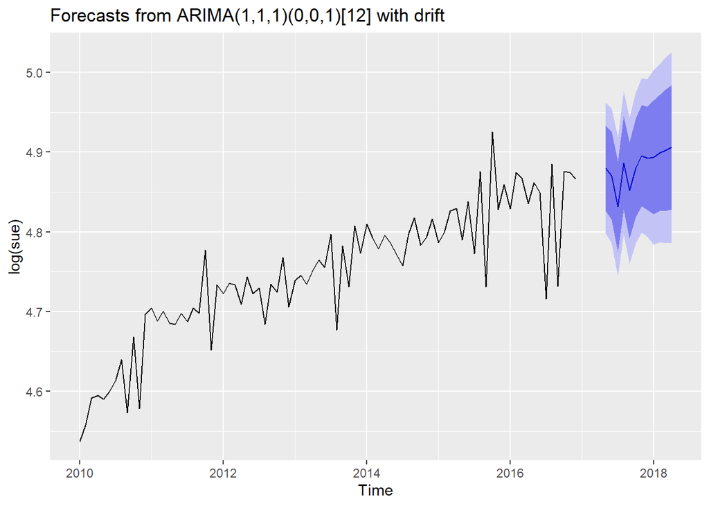

```r
autoplot(forecast(fit3, h=12))
```

## 6.2 Örnek: Google hisse fiyatları

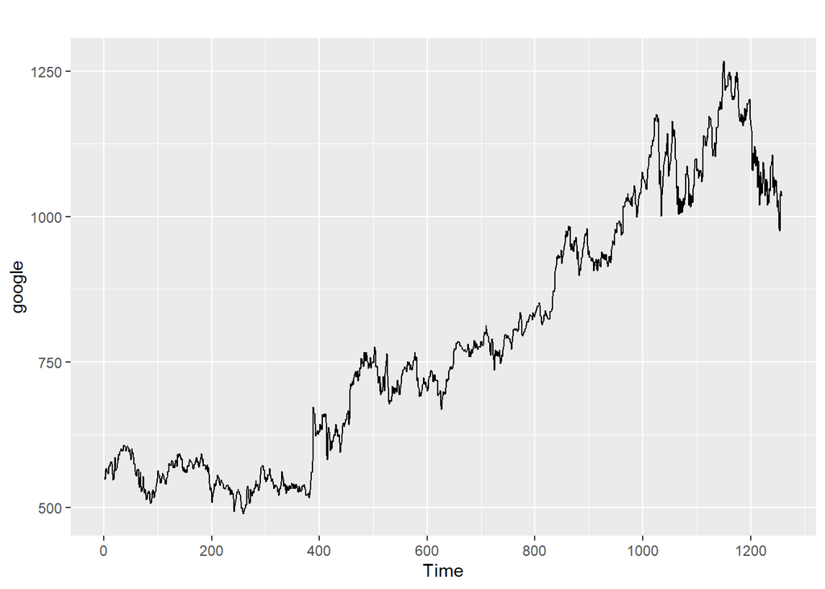

```r
# google günlük hisse verileri
library(tsibble)
library(tsibbledata)
google <- gafa_stock %>% filter(Symbol == "GOOG")
google <- ts(google$Close, frequency = 1)
autoplot(google)
```

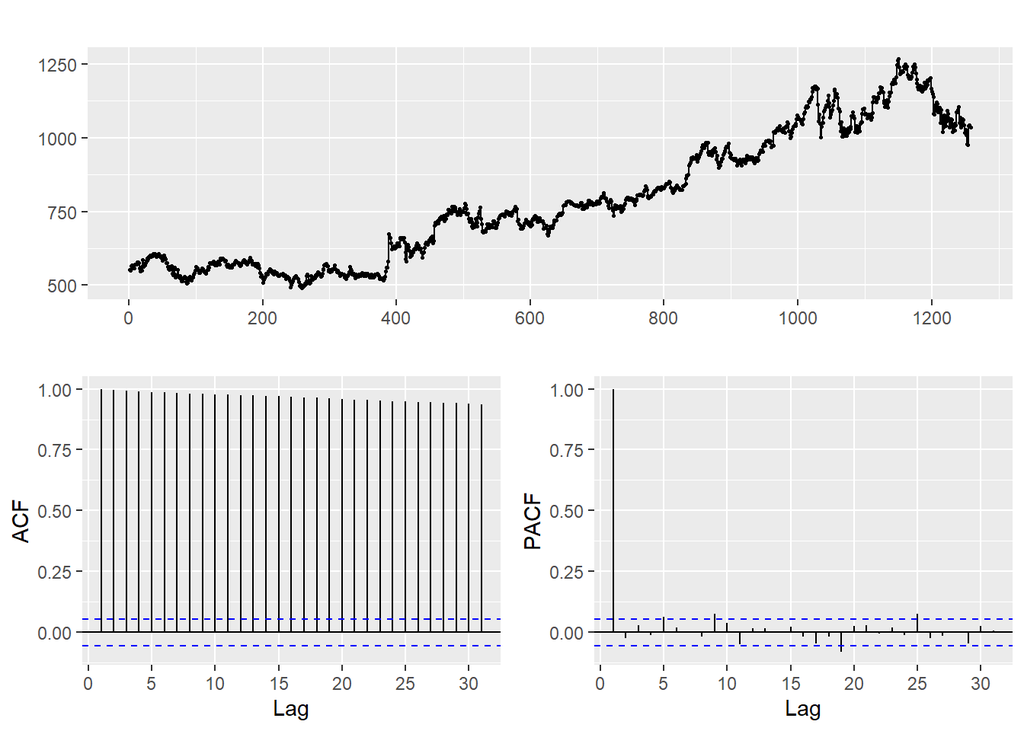

```r
ggtsdisplay(google)
```

Birim kök testi:

```r
# KPSS
library(feasts)
unitroot_kpss(log(google))
```

```
##   kpss_stat kpss_pvalue
##    15.09458     0.01000
```

Google hisse fiyatının durağan olduğunu söyleyen boş hipotez reddedilir. Birinci farkını alarak tekrar testi hesaplayalım:

```r
unitroot_kpss(diff(log(google)))
```

```
##   kpss_stat kpss_pvalue
##  0.04963165  0.10000000
```

P değeri yeterince büyük olduğu için boş hipotez kabul edilir. Sonuç olarak Google serisi birinci farkı alındığında durağanlaşmaktadır.

```r
unitroot_ndiffs(log(google))
```

```
## ndiffs
##      1
```

```r
unitroot_nsdiffs(log(google))
```

```
## nsdiffs
##       0
```

Birinci fark almaya gerek vardır ancak mevsimsel fark almaya gerek yoktur.

Logaritmik birinci fark serisinin ACF ve PACF grafiklerini inceleyelim:

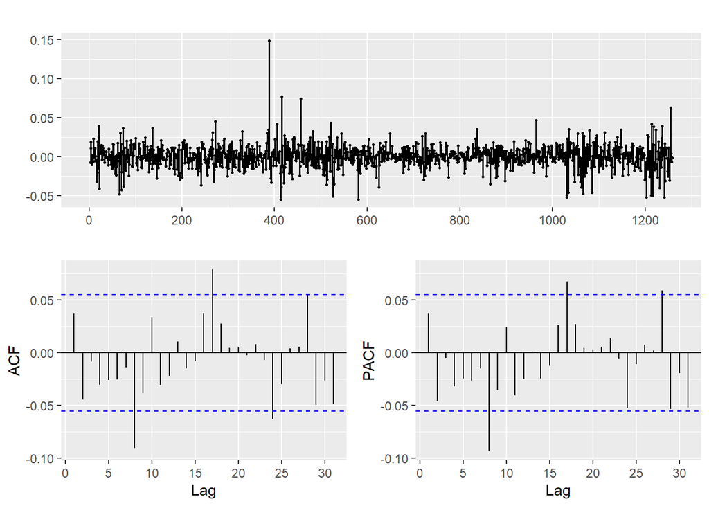

```r
ggtsdisplay(diff(log(google)))
```

ARIMA(1,1,1) modeli deneyelim:

```r
goog_fit1 <- Arima(log(google), order = c(1,1,1))
goog_fit1
```

```
## Series: log(google)
## ARIMA(1,1,1)
##
## Coefficients:
##           ar1     ma1
##       -0.6767  0.7187
## s.e.   0.2631  0.2471
##
## sigma^2 = 0.0002152:  log likelihood = 3524.55
## AIC=-7043.09   AICc=-7043.07   BIC=-7027.68
```

Kalıntı analizi:

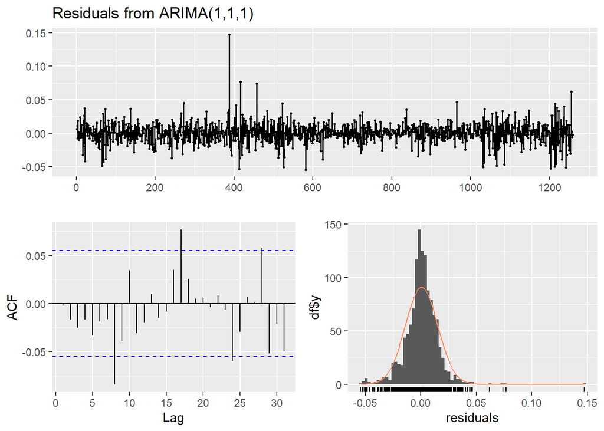

```
##
##  Ljung-Box test
##
## data:  Residuals from ARIMA(1,1,1)
## Q* = 16.12, df = 8, p-value = 0.04069
##
## Model df: 2.   Total lags used: 10
```

```r
checkresiduals(goog_fit1)
```

Kalıntılar white noise değil. ARIMA(2,1,1) deneyelim:

```r
goog_fit2 <- Arima(log(google), order = c(2,1,1))
goog_fit2
```

```
## Series: log(google)
## ARIMA(2,1,1)
##
## Coefficients:
##          ar1     ar2      ma1
##       0.9001  -0.073  -0.8651
## s.e.  0.0772   0.029   0.0728
##
## sigma^2 = 0.0002144:  log likelihood = 3527.3
## AIC=-7046.6   AICc=-7046.57   BIC=-7026.05
```

Kalıntı analizi:

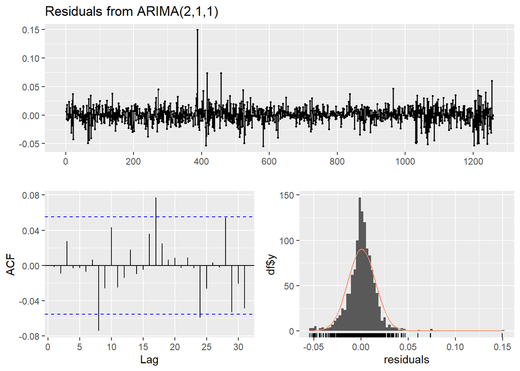

```
##
##  Ljung-Box test
##
## data:  Residuals from ARIMA(2,1,1)
## Q* = 11.458, df = 7, p-value = 0.1198
##
## Model df: 3.   Total lags used: 10
```

```r
checkresiduals(goog_fit2)
```

Önceki modele göre AICc daha küçük olduğu için ARIMA(2,1,1) tercih edilebilir (bu iki model arasında).